# RPMI_YPD combined Plate Reader analysis

Liz Hughes

23/11/2022

This analysis takes parts from Rmd files RPMI_PR_20200728.Rmd and nYPD_PR_20200807.Rmd to create a combined figure. Test WT H99 and Gat 201 deletion mutants 003(Madhani) and 004(Bahn)in RPMI and YPD at 37 degrees in TECAN plate reader. 7 Bioreps, 3 Techreps each. (NB only 2 Techreps for Biorep 7) Grow 5ml culture from colony (1 colony = 1 Biorep)in YPD, 30C, 250 rpm ON. Seed at OD 600nm = 0.2 , 200 ul per well. Run for 3 days.

```r
library(tidyverse)
library(reshape2)
library(cowplot)
library(extrafont)
```

```r
read_platereader_csv <- function(file, ...) {
  # read plate reader data in .csv format and convert time to hours, from seconds.
  readr::read_csv(file = file, ...) %>%
    dplyr::mutate(Time = Time/3600)
}

read_platemap_csv <- function(file, strain_df = NULL, ...) {
  platemap <- readr::read_csv(file = file, ...)
  if ( !is.null(strain_df) ) {
    platemap <- platemap %>%
      dplyr::left_join(strain_df, by = "Strain")
  }
  platemap
}

reshape_annotate_rawod <- function(rawod, platemap,
                                   od.name = "OD595",
                                   melt.id = "Time",
                                   well.name = "Well") {
  rawod %>%
    # Tidy the data using the melt function from reshape2
    reshape2::melt(id = melt.id,
                   variable.name = well.name,
                   value.name =  od.name) %>%
    # Annotate by joining with the platemap
    inner_join(platemap, by = well.name)
}

summarise_OD_fixed <- function(annotated_od, od.name = "OD595", ...) {
  # summarise OD fixed value across many times
  # here use `...` input to pass conditions to filter
  # e.g. summarise_OD_fixed(annotated_od, od.name = "OD595", is.na(Strain))
  annotated_od %>%
    dplyr::filter(...) %>%
    dplyr::summarise(OD_median = median(OD595),
                     OD_mean   = mean(OD595),
                     OD_max    = max(OD595),
                     OD_min    = min(OD595),
                     .groups = "keep")
}

summarise_OD_bytime <- function(annotated_od, od.name = "OD595", groups = "Time", ...) {
  # summarise OD at each time
  # here use `...` input to pass conditions to filter
  # e.g. summarise_OD_bytime(annotated_od, od.name = "OD595", groups = "Time", is.na(Strain))
  annotated_od %>%
    dplyr::filter(...) %>%
    dplyr::group_by(Time) %>%
    dplyr::summarise(OD_median_time = median(OD595),
                     OD_mean_time   = mean(OD595),
                     OD_max_time    = max(OD595),
                     OD_min_time    = min(OD595),
                     .groups = "keep")
}

normalise_OD_2ways <- function(annotatedod, ...) {
  # normalise OD across a plate
  # will NOT work if there are multiple media in a plate; that would require an extra group_by or filtering internally.
  # here use `...` input to pass conditions to filter
  # e.g. normalise_OD(annotated_od, is.na(Strain))
  # e.g. normalise_OD(annotated_od, Well %in% c("A1","A2","A3"))

  normvalues_fixed <-
    summarise_OD_fixed(annotatedod, od.name = "OD595", ...)
  normvalues_bytime <-
    summarise_OD_bytime(annotatedod, od.name = "OD595", groups = "Time", ...)
  annotatedod %>%
    mutate(OD_corrected_fixed = OD595 - normvalues_fixed$OD_median) %>%
    left_join(normvalues_bytime, by = "Time") %>%
    mutate(OD_corrected_time = OD595 - OD_median_time)
}
```

```r
theme_set(
  theme_cowplot(font_size = 12, font_family = "Arial",
                rel_large = 1) +
    theme(strip.background = element_blank(),
          panel.border =
            element_rect(color = "grey90",
                         fill = NA,
                         linetype = 1,
                         size = 1),
          panel.grid.major.y =
            element_line(size = 0.5,
                         colour = "grey90"))
)

scale_time_hrs <-
  scale_x_continuous(name = "Time (hours)",
                     breaks = c(0, 12, 24, 48, 72),
                     limits = c(0, 72),
                     expand = c(0, 0))
```

# Set up data frame of nice strain names, colours, styles.

```r
strain_df <- tibble( Strain = c("H99", "Gat201(B)", "Gat201(M)", "C26", "C30" ),
                     Strain_nice = c("GAT201", "gat201∆b","gat201∆m", "GAT201-C1", "GAT201-C2"),
                     colour = c("grey20", "magenta3", "darkred", "blue3", "cyan4"))

scale_color_strain <-
  scale_color_manual("Strain",
                     breaks = strain_df$Strain_nice,
                     values = strain_df$colour)
```

# Read in transposed data as csv file RPMI

```r
rawod_RPMI <-
  read_platereader_csv("../Input/20200728_EH_PR2_RPMI_WT_Gat201TRSP.csv")
```

# Read in the Plate map data from csv file RPMI

Also combine with nice strain names for display.

```r
platemap_RPMI <-
  read_platemap_csv("../Input/20200728-PR2_SetupCSV.csv",
                    strain_df = strain_df)

head(platemap_RPMI, n=10)
```

```
## # A tibble: 10 × 7
##    Well  Strain Biorep Techrep Medium Strain_nice colour
##    <chr> <chr>   <dbl>   <dbl> <chr>  <chr>       <chr>
##  1 A1    <NA>       NA      NA RPMI   <NA>        <NA>
##  2 A2    <NA>       NA      NA RPMI   <NA>        <NA>
##  3 A3    <NA>       NA      NA RPMI   <NA>        <NA>
##  4 A4    <NA>       NA      NA RPMI   <NA>        <NA>
##  5 A5    <NA>       NA      NA RPMI   <NA>        <NA>
##  6 A6    <NA>       NA      NA RPMI   <NA>        <NA>
##  7 A7    <NA>       NA      NA RPMI   <NA>        <NA>
##  8 A8    <NA>       NA      NA RPMI   <NA>        <NA>
##  9 A9    <NA>       NA      NA RPMI   <NA>        <NA>
## 10 A10   <NA>       NA      NA RPMI   <NA>        <NA>
```

# Reshape data and combine with the plate map, pairing them by Well RPMI

```r
annotated_RPMI <-
  reshape_annotate_rawod(rawod = rawod_RPMI, platemap = platemap_RPMI)
```

## Plot blank ODs RPMI

To find how stable the ODs of the blank wells are.

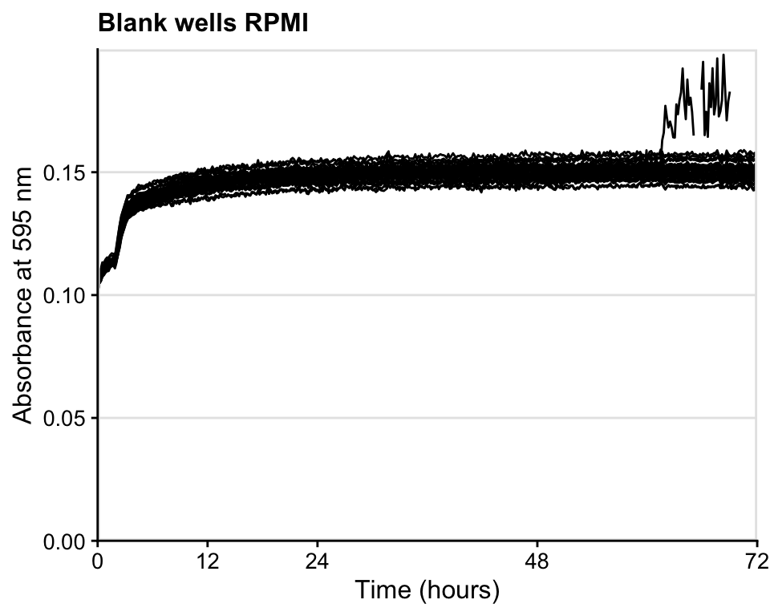

```r
ggplot(data=filter(annotated_RPMI, is.na(Strain)),
       aes(x=Time, y=OD595,  group = Well)) +
  geom_line() +
  scale_time_hrs +
  scale_y_continuous(limits = c(0, 0.2),
                     expand = c(0, 0),
                     breaks = c(0, 0.05, 0.1, 0.15)) +
  labs(title = "Blank wells RPMI", x="Time (hours)", y="Absorbance at 595 nm")
```

## Calculate median OD for blank wells for each growth medium RPMI

Remove well H2

```r
# filter out columns 1 and 12 as well?
blank_OD_summary_RPMI <-
  summarise_OD_fixed(annotated_RPMI, od.name = "OD595",
                     is.na(Strain),
                     Well != "H2")

print(blank_OD_summary_RPMI)
```

```
##   OD_median   OD_mean OD_max OD_min
## 1    0.1488 0.1471181 0.1592 0.1004
```

```r
blank_OD_time_RPMI <-
  summarise_OD_bytime(annotated_RPMI, od.name = "OD595",
                     is.na(Strain),
                     Well != "H2")

print(blank_OD_time_RPMI)
```

[output not shown]

# Subtract blank OD to make corrected OD and Plot OD_corrected v Time (hrs) RPMI

```r
normalisedOD_RPMI <-
  normalise_OD_2ways(annotated_RPMI, is.na(Strain))
```

## Plot OD all stat_summary(geom -“line”) Highlight summary line RPMI

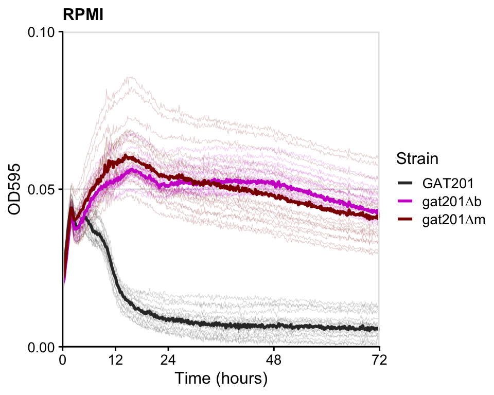

```r
RPMI_plot <- ggplot(data = normalisedOD_RPMI %>%
                      filter(!is.na(Strain)),
                    aes(x = Time, y = OD_corrected_time, color = Strain_nice)) +
  geom_line(aes(group = Well), size = 0.2, alpha = 0.2) +
  stat_summary(fun = "median", geom = "line", size = 1) +
  scale_time_hrs +
  # scale_y_continuous(limits = c(0, 0.9),
  #                    expand = c(0, 0),
  #                    breaks = c(0, 0.25, 0.5, 0.75)) +
  scale_y_continuous(limits = c(0, 0.1),
                     expand = c(0, 0),
                     breaks = c(0, 0.05, 0.1)) +
  labs(y = "OD595",
       title = "RPMI") +
  scale_color_strain

RPMI_plot
```

```r
ggsave("../Results/20200728_EH_PR2_RPMI_WT_Gat201TRSP_summaryplot.png",
       width = 5.1, height = 5)
```

# Read in transposed data as csv file YPD

```r
rawod_YPD <-
  read_platereader_csv("../Input/20200807_EH_PR4_YPD_WTGat201_TRSP.csv")
```

# Read in the Plate map data from csv file YPD

Also combine with nice strain names for display.

```r
platemap_YPD <-
  read_platemap_csv("../Input/20200807-PR4_SetupCSV.csv",
                    strain_df = strain_df)

head(platemap_YPD, n=10)
```

```
## # A tibble: 10 × 7
##    Well  Strain Biorep Techrep Medium Strain_nice colour
##    <chr> <chr>   <dbl>   <dbl> <chr>  <chr>       <chr>
##  1 A1    <NA>       NA      NA YPD    <NA>        <NA>
##  2 A2    <NA>       NA      NA YPD    <NA>        <NA>
##  3 A3    <NA>       NA      NA YPD    <NA>        <NA>
##  4 A4    <NA>       NA      NA YPD    <NA>        <NA>
##  5 A5    <NA>       NA      NA YPD    <NA>        <NA>
##  6 A6    <NA>       NA      NA YPD    <NA>        <NA>
##  7 A7    <NA>       NA      NA YPD    <NA>        <NA>
##  8 A8    <NA>       NA      NA YPD    <NA>        <NA>
##  9 A9    <NA>       NA      NA YPD    <NA>        <NA>
## 10 A10   <NA>       NA      NA YPD    <NA>        <NA>
```

# Reshape data and combine with the plate map, pairing them by Well YPD

```r
annotated_YPD <-
  reshape_annotate_rawod(rawod = rawod_YPD, platemap = platemap_YPD)
```

## Plot blank ODs YPD

To find how stable the ODs of the blank wells are.

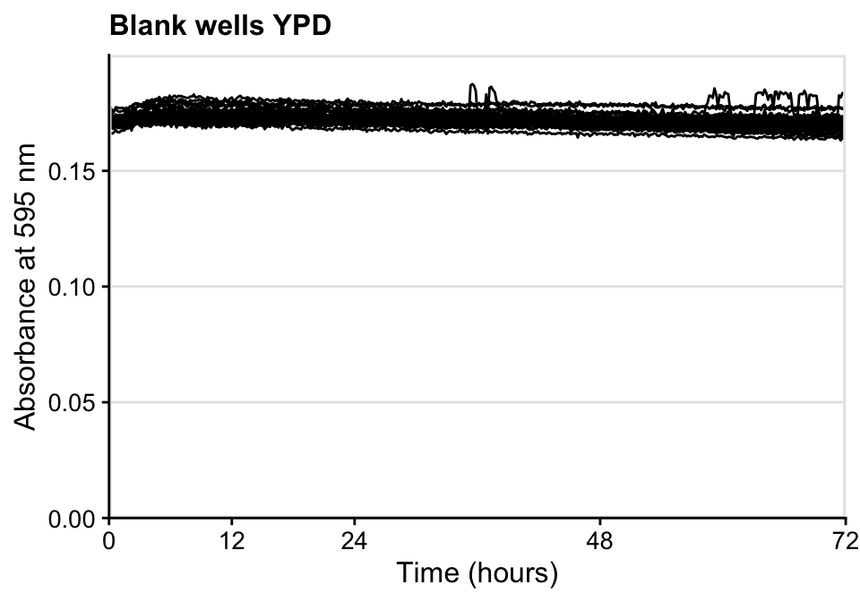

```r
ggplot(data=filter(annotated_YPD, is.na(Strain)),
           aes(x=Time, y=OD595,  group = Well)) +
  geom_line() +
  scale_time_hrs +
  scale_y_continuous(limits = c(0, 0.2),
                     expand = c(0, 0),
                     breaks = c(0, 0.05, 0.1, 0.15)) +
  labs(title = "Blank wells YPD", x="Time (hours)", y="Absorbance at 595 nm")
```

## Calculate median OD for blank wells for each growth medium YPD

```r
# filter out columns 1 and 12 as well?
blank_OD_summary_YPD <-
  summarise_OD_fixed(annotated_YPD, od.name = "OD595",
                     is.na(Strain))

print(blank_OD_summary_YPD)
```

```
##   OD_median  OD_mean OD_max OD_min
## 1    0.1721 0.172279 0.1875 0.1625
```

```r
blank_OD_time_YPD <-
  summarise_OD_bytime(annotated_YPD, od.name = "OD595",
                     is.na(Strain))

print(blank_OD_time_YPD)
```

[output not shown]

# Subtract blank OD to make corrected OD and Plot OD_corrected v Time (hrs) YPD

```r
normalisedOD_YPD <-
  normalise_OD_2ways(annotated_YPD, is.na(Strain))
```

## Plot OD all stat_summary(geom -“line”) Highlight summary line YPD

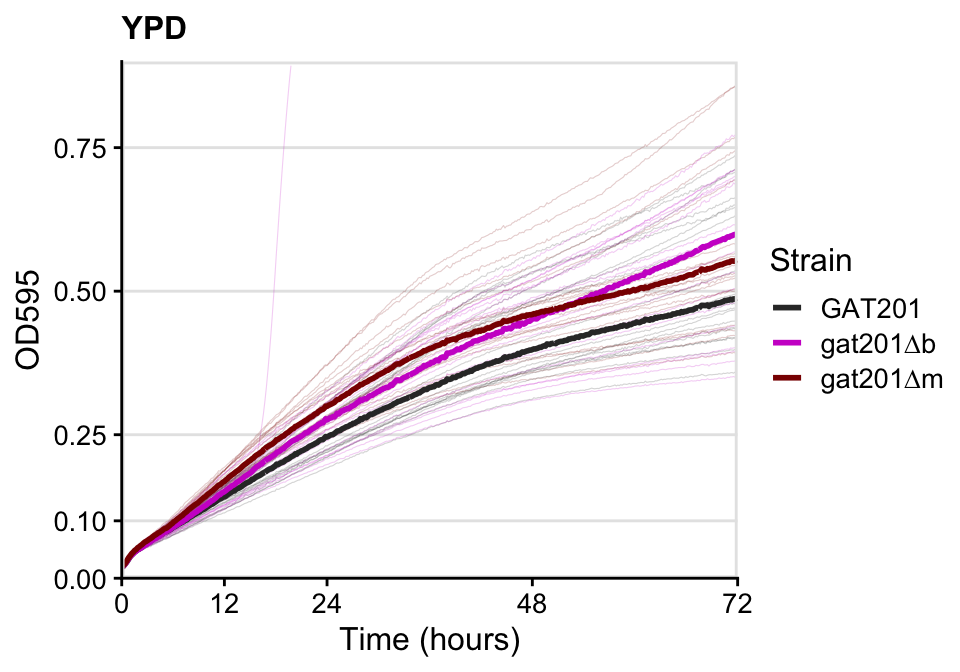

```r
YPD_plot <- ggplot(data = normalisedOD_YPD %>%
                      filter(!is.na(Strain)),
                    aes(x = Time, y = OD_corrected_time, color = Strain_nice)) +
  geom_line(aes(group = Well), size = 0.2, alpha = 0.2) +
  stat_summary(fun = "median", geom = "line", size = 1) +
  scale_time_hrs +
  scale_y_continuous(limits = c(0, 0.9),
                     expand = c(0, 0),
                     breaks = c(0, 0.1, 0.25, 0.5, 0.75)) +
  # scale_y_continuous(limits = c(0, 0.1),
  #                    expand = c(0, 0),
  #                    breaks = c(0, 0.05, 0.1)) +
  labs(y = "OD595",
       title = "YPD") +
  scale_color_strain

YPD_plot
```

```r
ggsave("../Results/20200807_EH_PR4_YPD_WTGat201_TRSP_summaryplot.png",
       width = 5.1, height = 5)
```

# Draft Multipanel Figure

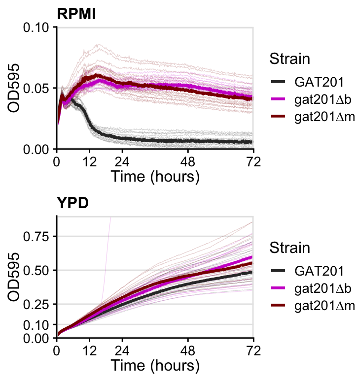

```r
plot_grid(
  RPMI_plot,
  YPD_plot,
  ncol = 1)
```

```r
ggsave(filename = "../results/fig_platereader.png", width = 3.75, height = 4)
```

```r
ggsave(filename = "../results/fig_platereader.svg", width = 3.75, height = 4)
```